# perceptual

#### Q1: Question response correctly identifies the independent and dependent variables in the experiment.

Independent Variable:-Color Congruency

Dependent Variables:-The time that it takes to name the ink color

#### Q2a: Null and alternative hypotheses are clearly stated in words and mathematically. Symbols in the mathematical statement are defined

The null hypothesis is considered the mean time taken for recognising colour for congruent words is equal to or greater than the mean time taken for incongruent words

H0: There is no difference in population means of response time under incongruent and congruent conditions ( H0: μC = μI )

Ha: Population mean of the response time under incongruent condition will be significantly larger than the response time under congruent condition ( Ha: μC < μI )

So, this would be a one-tailed test as there are reasons to assume directionality beforehand.

Please refer to this link for more information about directional hypothesis

#### Q2b: A statistical test is proposed which will distinguish the proposed hypotheses. Any assumptions made by the statistical test are addressed.

The mean time taken to recognising the congruent words(14.051125000000004) is less as compared to the time taken to recognising Incongruent words(22.01591666666667)

I am using t-test because size of data is small and how the means of two sets of data differ from one another when variance is not given.

```python
import math
import seaborn as sea
import numpy as np
import pandas as pd
import matplotlib.pyplot as plot
import scipy.stats as stats

data = pd.read_csv("stroopdata.csv")


#mean
Cmean = data['Congruent'].mean();
Imean = data['Incongruent'].mean();

print('Mean of Congruent:-',Cmean);
print('Mean of Incongruent:-',Imean);
```

```
Mean of Congruent:- 14.051125000000004
Mean of Incongruent:- 22.01591666666667
```

#### Q3: Descriptive statistics, including at least one measure of centrality and one measure of variability, have been computed for the dataset’s groups

```python
#Median
Cmedian = data['Congruent'].median();
Imedian = data['Incongruent'].median();
#Standard deviation
CStandardDeviation = data['Congruent'].std();
IStandardDeviation = data['Incongruent'].std();

print('Mean of Congruent:-',Cmean);
print('Mean of Incongruent:-',Imean);
print('Median of Congruent:-',Cmedian);
print('Median of Incongruent:-',Imedian);
print('Standard Deviation  of Congruent:- ',CStandardDeviation);
print('Standard Deviation  of  Incongruent:- ',IStandardDeviation);
```

```
Mean of Congruent:- 14.051125000000004
Mean of Incongruent:- 22.01591666666667
Median of Congruent:- 14.3565
Median of Incongruent:- 21.0175
Standard Deviation  of Congruent:-  3.559357957645195
Standard Deviation  of  Incongruent:-  4.797057122469138
```

#### Q4: One or two visualizations have been created that show off the data, including comments on what can be observed in the plot or plots.

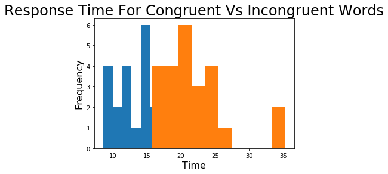

```python
# this code was throwing warning so I have commented it
# sea.distplot(data['Congruent'],label = "Congruent");
# sea.distplot(data['Incongruent'],label = "Incongruent");
# plot.xlabel("Time");
# plot.ylabel("Frequency");
# plot.title("Response Time For Congruent Vs Incongruent Words");
# plot.legend();


plot.xlabel("Time",fontsize=16);
plot.ylabel("Frequency",fontsize=16);
plot.title("Response Time For Congruent Vs Incongruent Words",fontsize=24);

con_array = np.array(data.Congruent)
# incongruent group to numpy array
incon_array = np.array(data.Incongruent)
# distribution of congruent group
plot.hist(con_array);
# distribution of incongruent group
plot.hist(incon_array);
```

#### Q5: A statistical test has been correctly performed and reported, including test statistic, p-value, and test result. The test results are interpreted in terms of the experimental task performed. Alternatively, students may use a bootstrapping approach to simulate the results of a traditional hypothesis test.

```python
stats.ttest_rel(data['Incongruent'],data['Congruent'],axis=0)
```

```
Ttest_relResult(statistic=8.020706944109957, pvalue=4.103000585711178e-08)
```

```python
data['difference']= data['Incongruent'] - data['Congruent']
data['difference'].describe()
```

```
count    24.000000
mean      7.964792
std       4.864827
min       1.950000
25%       3.645500
50%       7.666500
75%      10.258500
max      21.919000
Name: difference, dtype: float64
```

```python
stats.t.ppf(0.95,23)
```

```
1.7138715277470473
```

For a confidence level of 95% and 23 degrees of freedom, our t-critical is 1.7138715277470473

And our t-statistic is 8.020706944109957 so since the t-statistic value is greater that the t-critical value, we reject the null hypothesis. which pretty much match with what we expect.